# Supervised Learning - Foundations Project: ReCell

## Problem Statement

### Business Context

Buying and selling used phones and tablets used to be something that happened on a handful of online marketplace sites. But the used and refurbished device market has grown considerably over the past decade, and a new IDC (International Data Corporation) forecast predicts that the used phone market would be worth \$52.7bn by 2023 with a compound annual growth rate (CAGR) of 13.6% from 2018 to 2023. This growth can be attributed to an uptick in demand for used phones and tablets that offer considerable savings compared with new models.

Refurbished and used devices continue to provide cost-effective alternatives to both consumers and businesses that are looking to save money when purchasing one. There are plenty of other benefits associated with the used device market. Used and refurbished devices can be sold with warranties and can also be insured with proof of purchase. Third-party vendors/platforms, such as Verizon, Amazon, etc., provide attractive offers to customers for refurbished devices. Maximizing the longevity of devices through second-hand trade also reduces their environmental impact and helps in recycling and reducing waste. The impact of the COVID-19 outbreak may further boost this segment as consumers cut back on discretionary spending and buy phones and tablets only for immediate needs.

### Objective

The rising potential of this comparatively under-the-radar market fuels the need for an ML-based solution to develop a dynamic pricing strategy for used and refurbished devices. ReCell, a startup aiming to tap the potential in this market, has hired you as a data scientist. They want you to analyze the data provided and build a linear regression model to predict the price of a used phone/tablet and identify factors that significantly influence it.

### Data Description

The data contains the different attributes of used/refurbished phones and tablets. The data was collected in the year 2021. The detailed data dictionary is given below.

- brand_name: Name of manufacturing brand
- os: OS on which the device runs
- screen_size: Size of the screen in cm
- 4g: Whether 4G is available or not
- 5g: Whether 5G is available or not
- main_camera_mp: Resolution of the rear camera in megapixels
- selfie_camera_mp: Resolution of the front camera in megapixels
- int_memory: Amount of internal memory (ROM) in GB
- ram: Amount of RAM in GB
- battery: Energy capacity of the device battery in mAh
- weight: Weight of the device in grams
- release_year: Year when the device model was released
- days_used: Number of days the used/refurbished device has been used
- normalized_new_price: Normalized price of a new device of the same model in euros
- normalized_used_price: Normalized price of the used/refurbished device in euros

## Importing necessary libraries

```python
import pandas as pd
import numpy as np
import matplotlib.pyplot as plt
import seaborn as sns
from sklearn.model_selection import train_test_split
import statsmodels.api as sm
```

```python
from sklearn.metrics import mean_absolute_error,mean_squared_error
```

## Loading the dataset

```python
from google.colab import files
import io

try:
  uploaded
except NameError:
  uploaded=files.upload()

CData=pd.read_csv(io.BytesIO(uploaded["used_device_data.csv"]))
```

Upload widget is only available when the cell has been executed in the current browser session. Please rerun this cell to enable.

```
Saving used_device_data.csv to used_device_data.csv
```

Code taken from "LinearRegression_HandsOn-1.ipynb." Now, I know two ways to load the data set. As an asside, I like to give my dataset a name that relates to what it is. I don't have to do this, but I will be renaming it recell.

```python
recell=CData
```

## Data Overview

```python
recell.head(100)
```

[output not shown]

100 rows × 15 columns

```python
recell.info()
```

[output not shown]

```python
recell.shape
```

```
(3454, 15)
```

```python
recell.isnull().sum()
```

```
brand_name                 0
os                         0
screen_size                0
4g                         0
5g                         0
main_camera_mp           179
selfie_camera_mp           2
int_memory                 4
ram                        4
battery                    6
weight                     7
release_year               0
days_used                  0
normalized_used_price      0
normalized_new_price       0
dtype: int64
```

```python
recell.nunique()
```

```
brand_name                 34
os                          4
screen_size               142
4g                          2
5g                          2
main_camera_mp             41
selfie_camera_mp           37
int_memory                 15
ram                        12
battery                   324
weight                    555
release_year                8
days_used                 924
normalized_used_price    3094
normalized_new_price     2988
dtype: int64
```

To begin with, I observe that the recell has 3454 lines and 15 columns. Two of the columns, brand_name and os will probably be dropped because they contain too many categories for linear analysis. There are duplicate devices within the dataset, but this does not mean that there is duplicate information. Also, each device will not have exactly the same properties. One may be new, while another is used. The number of days a certain device was used may differ. What I also observce is that there are missing values that will have to be replaced. Some of the variables such as selfie_camera_mp, only have a few missing variables. Therfore, leaving them in place may not make a difference in the initial univatiate or bivariate analysis. However, main_camera_mp is missing 179 values. This must be addressed before any type of analysis. I will first replace the "nan: with NaN, which is recognized by Python, and then after copying the dataset, I will use the lambda function deecribed in the HandsOn Notebook to accomplish this. I will also need to replace the "yes" and "no" categories in 4g and 5g with nummbers and drop one of the variables to conduct the analysis. Then, I will convert the variables from category object to category int. That should be all I need to do before I conduct my linear analysis.

- Observations
- Sanity checks

## Replaceing the nans with NaNs

```python
recell.replace("nan",np.nan)
```

|  | brand_name | os | screen_size | 4g | 5g | main_camera_mp | selfie_camera_mp | int_memory | ram | battery | weight | release_year | days_used | normalized_used_price | normalized_new_price |
| --- | --- | --- | --- | --- | --- | --- | --- | --- | --- | --- | --- | --- | --- | --- | --- |
| 0 | Honor | Android | 14.50 | yes | no | 13.0 | 5.0 | 64.0 | 3.0 | 3020.0 | 146.0 | 2020 | 127 | 4.307572 | 4.715100 |
| 1 | Honor | Android | 17.30 | yes | yes | 13.0 | 16.0 | 128.0 | 8.0 | 4300.0 | 213.0 | 2020 | 325 | 5.162097 | 5.519018 |
| 2 | Honor | Android | 16.69 | yes | yes | 13.0 | 8.0 | 128.0 | 8.0 | 4200.0 | 213.0 | 2020 | 162 | 5.111084 | 5.884631 |
| 3 | Honor | Android | 25.50 | yes | yes | 13.0 | 8.0 | 64.0 | 6.0 | 7250.0 | 480.0 | 2020 | 345 | 5.135387 | 5.630961 |
| 4 | Honor | Android | 15.32 | yes | no | 13.0 | 8.0 | 64.0 | 3.0 | 5000.0 | 185.0 | 2020 | 293 | 4.389995 | 4.947837 |
| ... | ... | ... | ... | ... | ... | ... | ... | ... | ... | ... | ... | ... | ... | ... | ... |
| 3449 | Asus | Android | 15.34 | yes | no | NaN | 8.0 | 64.0 | 6.0 | 5000.0 | 190.0 | 2019 | 232 | 4.492337 | 6.483872 |
| 3450 | Asus | Android | 15.24 | yes | no | 13.0 | 8.0 | 128.0 | 8.0 | 4000.0 | 200.0 | 2018 | 541 | 5.037732 | 6.251538 |
| 3451 | Alcatel | Android | 15.80 | yes | no | 13.0 | 5.0 | 32.0 | 3.0 | 4000.0 | 165.0 | 2020 | 201 | 4.357350 | 4.528829 |
| 3452 | Alcatel | Android | 15.80 | yes | no | 13.0 | 5.0 | 32.0 | 2.0 | 4000.0 | 160.0 | 2020 | 149 | 4.349762 | 4.624188 |
| 3453 | Alcatel | Android | 12.83 | yes | no | 13.0 | 5.0 | 16.0 | 2.0 | 4000.0 | 168.0 | 2020 | 176 | 4.132122 | 4.279994 |

3454 rows × 15 columns

## Replace strings with digits and change categories from object to int.

```python
recell["4g"]=recell["4g"].replace({"yes":1,"no":2})
recell["5g"]=recell["5g"].replace({"yes":1,"no":2})
recell["4g"]=recell["4g"].astype(int)
recell["5g"]=recell["5g"].astype(int)
```

```python
recell.info()
```

```
<class 'pandas.core.frame.DataFrame'>
RangeIndex: 3454 entries, 0 to 3453
Data columns (total 15 columns):
 #   Column                 Non-Null Count  Dtype
---  ------                 --------------  -----
 0   brand_name             3454 non-null   object
 1   os                     3454 non-null   object
 2   screen_size            3454 non-null   float64
 3   4g                     3454 non-null   int64
 4   5g                     3454 non-null   int64
 5   main_camera_mp         3275 non-null   float64
 6   selfie_camera_mp       3452 non-null   float64
 7   int_memory             3450 non-null   float64
 8   ram                    3450 non-null   float64
 9   battery                3448 non-null   float64
 10  weight                 3447 non-null   float64
 11  release_year           3454 non-null   int64
 12  days_used              3454 non-null   int64
 13  normalized_used_price  3454 non-null   float64
 14  normalized_new_price   3454 non-null   float64
dtypes: float64(9), int64(4), object(2)
memory usage: 404.9+ KB
```

## Exploratory Data Analysis (EDA)

- EDA is an important part of any project involving data.
- It is important to investigate and understand the data better before building a model with it.
- A few questions have been mentioned below which will help you approach the analysis in the right manner and generate insights from the data.
- A thorough analysis of the data, in addition to the questions mentioned below, should be done.

**Questions**:

1. What does the distribution of normalized used device prices look like?
2. What percentage of the used device market is dominated by Android devices?
3. The amount of RAM is important for the smooth functioning of a device. How does the amount of RAM vary with the brand?
4. A large battery often increases a device's weight, making it feel uncomfortable in the hands. How does the weight vary for phones and tablets offering large batteries (more than 4500 mAh)?
5. Bigger screens are desirable for entertainment purposes as they offer a better viewing experience. How many phones and tablets are available across different brands with a screen size larger than 6 inches?
6. A lot of devices nowadays offer great selfie cameras, allowing us to capture our favorite moments with loved ones. What is the distribution of devices offering greater than 8MP selfie cameras across brands?
7. Which attributes are highly correlated with the normalized price of a used device?

## General analysis. Note: This code was also taken from "LinearRegression_Hands)n Notebook.This gives an overview of the entire dataset and all of its variables using a single short code block.

```python
recell.describe()
```

|  | screen_size | 4g | 5g | main_camera_mp | selfie_camera_mp | int_memory | ram | battery | weight | release_year | days_used | normalized_used_price | normalized_new_price |
| --- | --- | --- | --- | --- | --- | --- | --- | --- | --- | --- | --- | --- | --- |
| count | 3454.000000 | 3454.000000 | 3454.000000 | 3275.000000 | 3452.000000 | 3450.000000 | 3450.000000 | 3448.000000 | 3447.000000 | 3454.000000 | 3454.000000 | 3454.000000 | 3454.000000 |
| mean | 13.713115 | 1.323972 | 1.955993 | 9.460208 | 6.554229 | 54.573099 | 4.036122 | 3133.402697 | 182.751871 | 2015.965258 | 674.869716 | 4.364712 | 5.233107 |
| std | 3.805280 | 0.468057 | 0.205140 | 4.815461 | 6.970372 | 84.972371 | 1.365105 | 1299.682844 | 88.413228 | 2.298455 | 248.580166 | 0.588914 | 0.683637 |
| min | 5.080000 | 1.000000 | 1.000000 | 0.080000 | 0.000000 | 0.010000 | 0.020000 | 500.000000 | 69.000000 | 2013.000000 | 91.000000 | 1.536867 | 2.901422 |
| 25% | 12.700000 | 1.000000 | 2.000000 | 5.000000 | 2.000000 | 16.000000 | 4.000000 | 2100.000000 | 142.000000 | 2014.000000 | 533.500000 | 4.033931 | 4.790342 |
| 50% | 12.830000 | 1.000000 | 2.000000 | 8.000000 | 5.000000 | 32.000000 | 4.000000 | 3000.000000 | 160.000000 | 2015.500000 | 690.500000 | 4.405133 | 5.245892 |
| 75% | 15.340000 | 2.000000 | 2.000000 | 13.000000 | 8.000000 | 64.000000 | 4.000000 | 4000.000000 | 185.000000 | 2018.000000 | 868.750000 | 4.755700 | 5.673718 |
| max | 30.710000 | 2.000000 | 2.000000 | 48.000000 | 32.000000 | 1024.000000 | 12.000000 | 9720.000000 | 855.000000 | 2020.000000 | 1094.000000 | 6.619433 | 7.847841 |

When I examine these values, int_memory appears to be the only one with a significant difference between the mean (54.57) and the median (32.0). There may be outliers present in this distribution that can be eliminated to reduce the skew.

```python
recell.attr=recell.iloc[:,0:15]
```

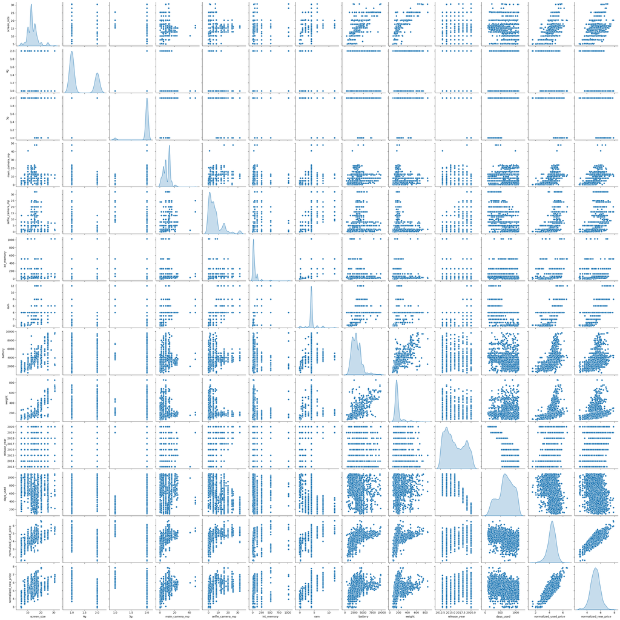

```python
sns.pairplot(recell.attr,diag_kind="kde")
```

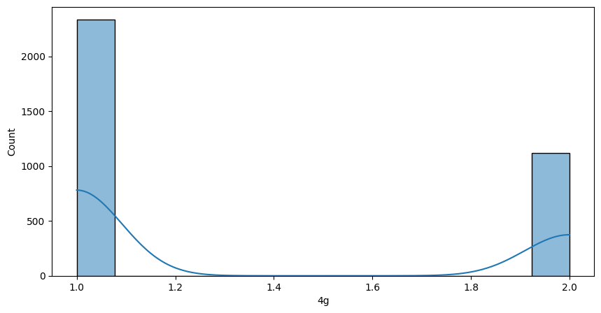

```python
plt.figure(figsize=(10,5))
sns.histplot(data=recell,x="4g",kde=True)
```

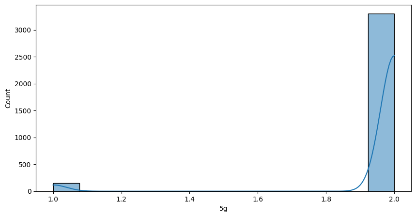

```python
plt.figure(figsize=(10,5))
sns.histplot(data=recell,x="5g",kde=True)
```

```python
g_cols4=["4g"]
for columns in g_cols4:
  print(recell[columns].value_counts())
```

```
1    2335
2    1119
Name: 4g, dtype: int64
```

```python
g_cols5=["5g"]
for columns in g_cols5:
  print(recell[columns].value_counts())
```

```
2    3302
1     152
Name: 5g, dtype: int64
```

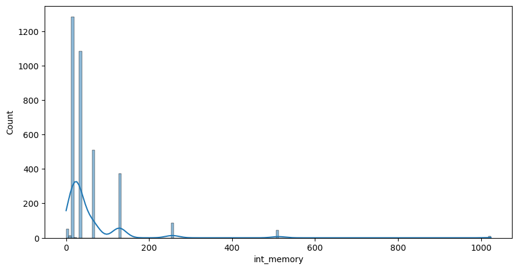

```python
plt.figure(figsize=(10,5))
sns.histplot(data=recell,x="int_memory",kde=True)
```

```python
int_cols=["int_memory"]
for columns in int_cols:
  print(recell[columns].value_counts(normalize=True))
```

```
16.00      0.371884
32.00      0.313913
64.00      0.147536
128.00     0.107826
256.00     0.024928
512.00     0.012754
0.06       0.005217
0.10       0.004928
8.00       0.003478
4.00       0.002899
1024.00    0.002319
0.50       0.001159
0.20       0.000580
24.00      0.000290
0.01       0.000290
Name: int_memory, dtype: float64
```

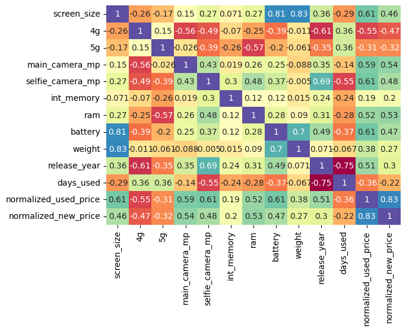

```python
sns.heatmap(data=recell[["screen_size","4g","5g","main_camera_mp",
                         "selfie_camera_mp","int_memory","ram","battery",
                         "weight","release_year","days_used","normalized_used_price",
                         "normalized_new_price"]].corr(),
            annot=True,cbar=False,cmap="Spectral")
```

For the purspose of this analysis, values above 0.06 with be considered nominally correlated and values above 0.80 to be highly correlated. There are high correlations between screen_size and battery (0.81) and screensize and weight (0.83). The relationship between battery size and weight is obvious. However, the relationship is not although this close correlation may indicate a case of colinerarity since the larger the battery, the heavier the device.

There is a nominal negative correlation between release year and 4g (-0.61). This makes sense because the older the phone, the less likely it is to have 4g capabilities.

There is a nominal correlation between selfie camera mp and release year (0.69). This likely indicates that the newer the phone, the greater the number of megapixels a camera will generate. There is also a nominal correlation between selfie camera mp and normalized used price. This likely indicates that the more megapixels per inch a device camera generates, the greater the resale value.

There is a nominal correlation between battery and weight (0.70), which we have already discussed. There is also a nominal correlation between battery and normalized used price. The longer the battery life, the greater the resale value.

There is a nominal negative correlation between realease year and days used (-0.75). That is becuase as the year of the phone increases, the number of days used possible decreases.

Finally, with regard to normalized used price, there is a nominal correlation with screen size (0.61). The larger the screensize, the more the resale price. There is also a strong correlation between normalized used and normalized new prices. This bodes well for the industry indicating that more expensive new devices will sell for higher prices than cheaper ones, also that devices hold their value over time (Code taken from FoodHub Project).

## 1. Distribution of normalized used prices

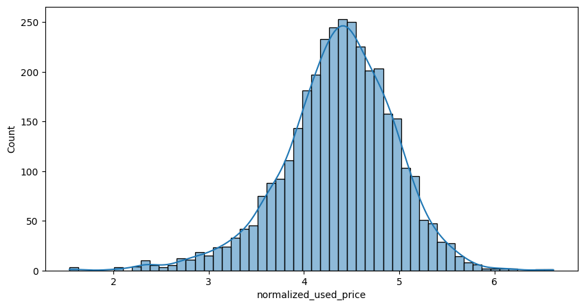

```python
plt.figure(figsize=(10,5))
sns.histplot(data=recell,x="normalized_used_price",kde=True)
```

As stated earlier, this distribution tends toward normal.

## 2. Percentage of the used market dominated by android devices

```python
android_per=["os"]
for columns in android_per:
  print(recell[columns].value_counts(normalize=True))
```

```
Android    0.930515
Others     0.039664
Windows    0.019398
iOS        0.010423
Name: os, dtype: float64
```

## 3. How does RAM vary by brand?

```python
ram_brand=pd.crosstab(recell["brand_name"],recell["ram"]).reset_index()
```

```python
ram_brand
```

| ram | brand_name | 0.02 | 0.03 | 0.25 | 0.5 | 1.0 | 1.5 | 2.0 | 3.0 | 4.0 | 6.0 | 8.0 | 12.0 |
| --- | --- | --- | --- | --- | --- | --- | --- | --- | --- | --- | --- | --- | --- |
| 0 | Acer | 0 | 0 | 0 | 0 | 1 | 0 | 1 | 0 | 49 | 0 | 0 | 0 |
| 1 | Alcatel | 0 | 0 | 7 | 3 | 10 | 0 | 2 | 1 | 98 | 0 | 0 | 0 |
| 2 | Apple | 0 | 0 | 0 | 0 | 0 | 0 | 1 | 2 | 34 | 2 | 0 | 0 |
| 3 | Asus | 0 | 0 | 0 | 0 | 0 | 0 | 2 | 0 | 117 | 1 | 2 | 0 |
| 4 | BlackBerry | 0 | 0 | 1 | 0 | 0 | 0 | 0 | 0 | 21 | 0 | 0 | 0 |
| 5 | Celkon | 0 | 0 | 21 | 0 | 0 | 0 | 0 | 0 | 12 | 0 | 0 | 0 |
| 6 | Coolpad | 0 | 0 | 0 | 0 | 0 | 0 | 0 | 1 | 21 | 0 | 0 | 0 |
| 7 | Gionee | 0 | 0 | 1 | 0 | 0 | 0 | 0 | 0 | 55 | 0 | 0 | 0 |
| 8 | Google | 0 | 0 | 0 | 0 | 0 | 0 | 0 | 0 | 11 | 4 | 0 | 0 |
| 9 | HTC | 0 | 0 | 0 | 0 | 0 | 0 | 0 | 4 | 104 | 2 | 0 | 0 |
| 10 | Honor | 0 | 0 | 0 | 0 | 0 | 0 | 6 | 10 | 70 | 14 | 16 | 0 |
| 11 | Huawei | 0 | 0 | 2 | 0 | 2 | 0 | 4 | 2 | 179 | 34 | 26 | 2 |
| 12 | Infinix | 0 | 0 | 0 | 0 | 0 | 0 | 6 | 2 | 2 | 0 | 0 | 0 |
| 13 | Karbonn | 0 | 0 | 5 | 0 | 0 | 0 | 0 | 0 | 24 | 0 | 0 | 0 |
| 14 | LG | 0 | 0 | 1 | 2 | 4 | 0 | 6 | 14 | 162 | 6 | 6 | 0 |
| 15 | Lava | 0 | 0 | 4 | 2 | 0 | 0 | 2 | 0 | 28 | 0 | 0 | 0 |
| 16 | Lenovo | 0 | 0 | 2 | 0 | 2 | 0 | 8 | 2 | 151 | 6 | 0 | 0 |
| 17 | Meizu | 0 | 0 | 0 | 0 | 0 | 0 | 2 | 0 | 48 | 8 | 4 | 0 |
| 18 | Micromax | 0 | 0 | 10 | 0 | 0 | 0 | 0 | 0 | 107 | 0 | 0 | 0 |
| 19 | Microsoft | 0 | 0 | 0 | 0 | 0 | 0 | 0 | 0 | 22 | 0 | 0 | 0 |
| 20 | Motorola | 0 | 0 | 0 | 0 | 0 | 0 | 12 | 2 | 88 | 2 | 0 | 2 |
| 21 | Nokia | 18 | 17 | 0 | 0 | 2 | 0 | 8 | 4 | 51 | 2 | 0 | 0 |
| 22 | OnePlus | 0 | 0 | 0 | 0 | 0 | 0 | 0 | 0 | 10 | 2 | 8 | 2 |
| 23 | Oppo | 0 | 0 | 0 | 0 | 2 | 0 | 2 | 6 | 85 | 6 | 24 | 4 |
| 24 | Others | 0 | 0 | 24 | 1 | 8 | 0 | 9 | 4 | 445 | 8 | 3 | 0 |
| 25 | Panasonic | 0 | 0 | 0 | 0 | 0 | 0 | 0 | 0 | 47 | 0 | 0 | 0 |
| 26 | Realme | 0 | 0 | 0 | 0 | 0 | 0 | 4 | 8 | 17 | 12 | 0 | 0 |
| 27 | Samsung | 0 | 0 | 2 | 0 | 1 | 1 | 6 | 7 | 301 | 10 | 6 | 7 |
| 28 | Sony | 0 | 0 | 0 | 0 | 0 | 0 | 0 | 0 | 84 | 1 | 1 | 0 |
| 29 | Spice | 0 | 0 | 2 | 0 | 0 | 0 | 0 | 0 | 28 | 0 | 0 | 0 |
| 30 | Vivo | 0 | 0 | 0 | 1 | 0 | 0 | 2 | 2 | 83 | 9 | 20 | 0 |
| 31 | XOLO | 0 | 0 | 0 | 0 | 0 | 0 | 0 | 0 | 49 | 0 | 0 | 0 |
| 32 | Xiaomi | 0 | 0 | 0 | 0 | 0 | 0 | 4 | 7 | 89 | 20 | 11 | 1 |
| 33 | ZTE | 0 | 0 | 1 | 0 | 2 | 0 | 3 | 3 | 123 | 5 | 3 | 0 |

The majority of devices have 4 gigabytes of RAM (Code taken from ENews Express Project).

## 4. How does device weight vary between phones and tablets?

```
<function matplotlib.pyplot.show(close=None, block=None)>
```

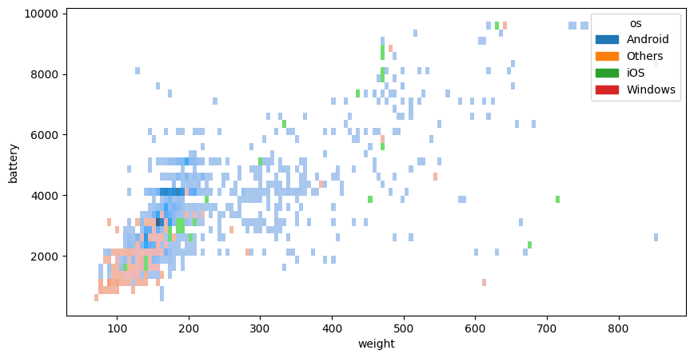

```python
plt.figure(figsize=(10,5))
sns.histplot(data=recell,x="weight",y="battery",hue="os")
plt.show
```

## 5. How many devices have a screen size greater than six inches or 15.25cm?

```python
screen_6=recell[recell.screen_size>15.24].reset_index()
```

```python
screen_6.shape
```

```
(1099, 16)
```

1099 devices have screen size greater than 6 inches or 15.24 cm (Code taken from FoodHub project).

## 6. Selfie Camera mp greater than 8 mp.

```python
selfie_8=pd.crosstab(recell["os"],recell["selfie_camera_mp"]>8.0).reset_index()
```

```python
selfie_8
```

| selfie_camera_mp | os | False | True |
| --- | --- | --- | --- |
| 0 | Android | 2561 | 653 |
| 1 | Others | 135 | 2 |
| 2 | Windows | 67 | 0 |
| 3 | iOS | 36 | 0 |

653 Android devices have a selfie camera with a resolution greater than 8mp. Two devices from the "Other" category and no devices from Windows or iOS have a selfie camers with a resolution greater than 8mp.

## 7. Variables correlated highly with

For the purpose of this analysis, nominal correlation is any number greater than 0.61 and high correlation is any number greater than 0.80. Three variables are correlated with normalized used price at a rate of 0.61. These are screen size, selfie camera mp and battery. All of these variables would make a used device more desirable. One variable is highly correlated with the normalized used price. That variable is normalized new price at a rate of 0.83. This suggests that a device will hold on to its value even when it enters the used market.

## Data Preprocessing

- Missing value treatment
- Feature engineering (if needed)
- Outlier detection and treatment (if needed)
- Preparing data for modeling
- Any other preprocessing steps (if needed)

## 1. Missing Value Treatment

Create the lambda function to replace NaN with median values. The limit of this lambda function is that it must be applied every time I want to use it. Otherwise, the data will revert to its original state. I will apply it when I get ready to set up the train/test sets. This was not explained in the videos. I had to figure this out using trial and error.

```python
m_filler=lambda x:x.fillna(x.median())
```

Code taken from LinearRegression_HandsOn Notebook.

## 2. Feature Engineering

First, I will make a copy of the dataset. Then, I will drop the first two variables (brand name and os) because there are so many categories that they are not suitable for linear regression. I have already made 4g and 5g into integers. Now, I will create dummy variables and drop the first one.

```python
recell=recell.drop(["brand_name"],axis=1)
```

```python
recell=recell.drop(["os"],axis=1)
```

```python
recell=pd.get_dummies(recell,columns=["4g","5g"],drop_first=True)
```

```python
recell.head()
```

|  | screen_size | main_camera_mp | selfie_camera_mp | int_memory | ram | battery | weight | release_year | days_used | normalized_used_price | normalized_new_price | 4g_2 | 5g_2 |
| --- | --- | --- | --- | --- | --- | --- | --- | --- | --- | --- | --- | --- | --- |
| 0 | 14.50 | 13.0 | 5.0 | 64.0 | 3.0 | 3020.0 | 146.0 | 2020 | 127 | 4.307572 | 4.715100 | 0 | 1 |
| 1 | 17.30 | 13.0 | 16.0 | 128.0 | 8.0 | 4300.0 | 213.0 | 2020 | 325 | 5.162097 | 5.519018 | 0 | 0 |
| 2 | 16.69 | 13.0 | 8.0 | 128.0 | 8.0 | 4200.0 | 213.0 | 2020 | 162 | 5.111084 | 5.884631 | 0 | 0 |
| 3 | 25.50 | 13.0 | 8.0 | 64.0 | 6.0 | 7250.0 | 480.0 | 2020 | 345 | 5.135387 | 5.630961 | 0 | 0 |
| 4 | 15.32 | 13.0 | 8.0 | 64.0 | 3.0 | 5000.0 | 185.0 | 2020 | 293 | 4.389995 | 4.947837 | 0 | 1 |

## Model Building - Linear Regression

Eliminate missing values and set up the Independant Variable (IV) and the Dependant Variable (DV).

```python
X=recell.apply(m_filler,axis=0).drop(["normalized_used_price"],axis=1)
```

```python
y=recell[["normalized_used_price"]].apply(m_filler,axis=0)
```

Add the constant.

```python
X=sm.add_constant(X)
```

Perform a train/test split using 30% of values for the test and 70% to train the model. Also, set the condition that each value will be selected randomly.

```python
X_train,X_test,y_train,y_test=train_test_split(X,y,test_size=0.30,random_state=1)
```

Checking the conditions.

```python
print(X_train.head())
```

```
      const  screen_size  main_camera_mp  selfie_camera_mp  int_memory  ram  \
3026    1.0        10.29             8.0               0.3        16.0  4.0
1525    1.0        15.34            13.0               5.0        32.0  4.0
1128    1.0        12.70            13.0               5.0        32.0  4.0
3003    1.0        12.83             8.0               5.0        16.0  4.0
2907    1.0        12.88            13.0              16.0        16.0  4.0

      battery  weight  release_year  days_used  normalized_new_price  4g_2  \
3026   1800.0   120.0          2014        819              4.796204     1
1525   4050.0   225.0          2016        585              5.434595     0
1128   2550.0   162.0          2015        727              5.137914     1
3003   3200.0   160.0          2015        800              5.189228     0
2907   2900.0   160.0          2017        560              5.016220     0

      5g_2
3026     1
1525     1
1128     1
3003     1
2907     1
```

```python
print(y_train.head())
```

```
      normalized_used_price
3026               4.087488
1525               4.448399
1128               4.315353
3003               4.282068
2907               4.456438
```

## Model Performance Check

Intial Performance check

```python
olsmodel=sm.OLS(y_train,X_train)
```

```python
olsresidue=olsmodel.fit()
```

```python
print(olsresidue.summary())
```

```
                              OLS Regression Results
=================================================================================
Dep. Variable:     normalized_used_price   R-squared:                       0.841
Model:                               OLS   Adj. R-squared:                  0.840
Method:                    Least Squares   F-statistic:                     1058.
Date:                   Fri, 12 May 2023   Prob (F-statistic):               0.00
Time:                           18:42:01   Log-Likelihood:                 92.350
No. Observations:                   2417   AIC:                            -158.7
Df Residuals:                       2404   BIC:                            -83.43
Df Model:                             12
Covariance Type:               nonrobust
========================================================================================
                           coef    std err          t      P>|t|      [0.025      0.975]
----------------------------------------------------------------------------------------
const                  -51.5350      8.958     -5.753      0.000     -69.101     -33.969
screen_size              0.0277      0.003      9.040      0.000       0.022       0.034
main_camera_mp           0.0207      0.001     14.855      0.000       0.018       0.023
selfie_camera_mp         0.0139      0.001     12.977      0.000       0.012       0.016
int_memory            8.566e-05    6.7e-05      1.278      0.201   -4.58e-05       0.000
ram                      0.0239      0.005      4.932      0.000       0.014       0.033
battery              -1.138e-05   7.06e-06     -1.611      0.107   -2.52e-05    2.47e-06
weight                   0.0008      0.000      6.687      0.000       0.001       0.001
release_year             0.0262      0.004      5.909      0.000       0.017       0.035
days_used              4.17e-05   3.05e-05      1.367      0.172   -1.81e-05       0.000
normalized_new_price     0.4184      0.011     37.675      0.000       0.397       0.440
4g_2                    -0.0462      0.015     -3.023      0.003      -0.076      -0.016
5g_2                     0.0196      0.031      0.631      0.528      -0.041       0.080
==============================================================================
Omnibus:                      220.922   Durbin-Watson:                   1.905
Prob(Omnibus):                  0.000   Jarque-Bera (JB):              397.449
Skew:                          -0.629   Prob(JB):                     4.96e-87
Kurtosis:                       4.537   Cond. No.                     7.45e+06
==============================================================================

Notes:
[1] Standard Errors assume that the covariance matrix of the errors is correctly specified.
[2] The condition number is large, 7.45e+06. This might indicate that there are
strong multicollinearity or other numerical problems.
```

The current model explains about 84% of factors that contribute to normalized used price. Since int_memory, battery, and days used contribute only a fraction of a percent of the value of R-Squared, I will drop them one at a time just to be sure R- squared doesn't change significantly.

```python
X_train2=X_train.drop(["int_memory"],axis=1)
```

```python
olsmodel_2=sm.OLS(y_train,X_train2)
```

```python
olsresidue_2=olsmodel_2.fit()
```

```python
print(olsresidue_2.summary())
```

```
                              OLS Regression Results
=================================================================================
Dep. Variable:     normalized_used_price   R-squared:                       0.841
Model:                               OLS   Adj. R-squared:                  0.840
Method:                    Least Squares   F-statistic:                     1154.
Date:                   Wed, 10 May 2023   Prob (F-statistic):               0.00
Time:                           00:51:47   Log-Likelihood:                 91.529
No. Observations:                   2417   AIC:                            -159.1
Df Residuals:                       2405   BIC:                            -89.58
Df Model:                             11
Covariance Type:               nonrobust
========================================================================================
                           coef    std err          t      P>|t|      [0.025      0.975]
----------------------------------------------------------------------------------------
const                  -52.3957      8.934     -5.865      0.000     -69.914     -34.877
screen_size              0.0276      0.003      8.999      0.000       0.022       0.034
main_camera_mp           0.0205      0.001     14.798      0.000       0.018       0.023
selfie_camera_mp         0.0142      0.001     13.363      0.000       0.012       0.016
ram                      0.0232      0.005      4.812      0.000       0.014       0.033
battery              -1.142e-05   7.06e-06     -1.617      0.106   -2.53e-05    2.43e-06
weight                   0.0008      0.000      6.678      0.000       0.001       0.001
release_year             0.0266      0.004      6.021      0.000       0.018       0.035
days_used             4.023e-05   3.05e-05      1.319      0.187   -1.96e-05       0.000
normalized_new_price     0.4214      0.011     38.761      0.000       0.400       0.443
4g_2                    -0.0440      0.015     -2.896      0.004      -0.074      -0.014
5g_2                     0.0144      0.031      0.468      0.640      -0.046       0.075
==============================================================================
Omnibus:                      218.400   Durbin-Watson:                   1.905
Prob(Omnibus):                  0.000   Jarque-Bera (JB):              401.134
Skew:                          -0.617   Prob(JB):                     7.85e-88
Kurtosis:                       4.569   Cond. No.                     7.43e+06
==============================================================================

Notes:
[1] Standard Errors assume that the covariance matrix of the errors is correctly specified.
[2] The condition number is large, 7.43e+06. This might indicate that there are
strong multicollinearity or other numerical problems.
```

No change.

```python
X_train3=X_train2.drop(["battery"],axis=1)
olsmodel_3=sm.OLS(y_train,X_train3)
olsresidue_3=olsmodel_3.fit()
```

```python
print(olsresidue_3.summary())
```

```
                              OLS Regression Results
=================================================================================
Dep. Variable:     normalized_used_price   R-squared:                       0.841
Model:                               OLS   Adj. R-squared:                  0.840
Method:                    Least Squares   F-statistic:                     1268.
Date:                   Wed, 10 May 2023   Prob (F-statistic):               0.00
Time:                           00:56:42   Log-Likelihood:                 90.216
No. Observations:                   2417   AIC:                            -158.4
Df Residuals:                       2406   BIC:                            -94.74
Df Model:                             10
Covariance Type:               nonrobust
========================================================================================
                           coef    std err          t      P>|t|      [0.025      0.975]
----------------------------------------------------------------------------------------
const                  -49.6461      8.773     -5.659      0.000     -66.850     -32.442
screen_size              0.0263      0.003      8.875      0.000       0.021       0.032
main_camera_mp           0.0203      0.001     14.708      0.000       0.018       0.023
selfie_camera_mp         0.0141      0.001     13.305      0.000       0.012       0.016
ram                      0.0231      0.005      4.795      0.000       0.014       0.033
weight                   0.0008      0.000      6.512      0.000       0.001       0.001
release_year             0.0253      0.004      5.818      0.000       0.017       0.034
days_used             4.156e-05   3.05e-05      1.363      0.173   -1.82e-05       0.000
normalized_new_price     0.4203      0.011     38.723      0.000       0.399       0.442
4g_2                    -0.0409      0.015     -2.716      0.007      -0.071      -0.011
5g_2                     0.0140      0.031      0.456      0.648      -0.046       0.074
==============================================================================
Omnibus:                      218.831   Durbin-Watson:                   1.906
Prob(Omnibus):                  0.000   Jarque-Bera (JB):              401.054
Skew:                          -0.618   Prob(JB):                     8.17e-88
Kurtosis:                       4.566   Cond. No.                     3.94e+06
==============================================================================

Notes:
[1] Standard Errors assume that the covariance matrix of the errors is correctly specified.
[2] The condition number is large, 3.94e+06. This might indicate that there are
strong multicollinearity or other numerical problems.
```

Still no change.

```python
X_train4=X_train3.drop(["days_used"],axis=1)
olsmodel_4=sm.OLS(y_train,X_train4)
olsresidue_4=olsmodel_4.fit()
```

```python
print(olsresidue_4.summary())
```

```
                              OLS Regression Results
=================================================================================
Dep. Variable:     normalized_used_price   R-squared:                       0.840
Model:                               OLS   Adj. R-squared:                  0.840
Method:                    Least Squares   F-statistic:                     1408.
Date:                   Wed, 10 May 2023   Prob (F-statistic):               0.00
Time:                           01:03:28   Log-Likelihood:                 89.283
No. Observations:                   2417   AIC:                            -158.6
Df Residuals:                       2407   BIC:                            -100.7
Df Model:                              9
Covariance Type:               nonrobust
========================================================================================
                           coef    std err          t      P>|t|      [0.025      0.975]
----------------------------------------------------------------------------------------
const                  -42.7511      7.169     -5.963      0.000     -56.809     -28.693
screen_size              0.0261      0.003      8.815      0.000       0.020       0.032
main_camera_mp           0.0206      0.001     14.983      0.000       0.018       0.023
selfie_camera_mp         0.0140      0.001     13.237      0.000       0.012       0.016
ram                      0.0232      0.005      4.813      0.000       0.014       0.033
weight                   0.0008      0.000      6.589      0.000       0.001       0.001
release_year             0.0218      0.004      6.155      0.000       0.015       0.029
normalized_new_price     0.4196      0.011     38.693      0.000       0.398       0.441
4g_2                    -0.0435      0.015     -2.908      0.004      -0.073      -0.014
5g_2                     0.0180      0.031      0.588      0.556      -0.042       0.078
==============================================================================
Omnibus:                      220.750   Durbin-Watson:                   1.906
Prob(Omnibus):                  0.000   Jarque-Bera (JB):              406.615
Skew:                          -0.621   Prob(JB):                     5.07e-89
Kurtosis:                       4.579   Cond. No.                     3.05e+06
==============================================================================

Notes:
[1] Standard Errors assume that the covariance matrix of the errors is correctly specified.
[2] The condition number is large, 3.05e+06. This might indicate that there are
strong multicollinearity or other numerical problems.
```

The value has now dropped 0.001%. I will now drop weight as a final value because it is said to only contribute 0.0008% of normalized used price.

```python
X_train5=X_train4.drop(["weight"],axis=1)
olsmodel_5=sm.OLS(y_train,X_train5)
olsresidue_5=olsmodel_5.fit()
```

```python
print(olsresidue_5.summary())
```

```
                              OLS Regression Results
=================================================================================
Dep. Variable:     normalized_used_price   R-squared:                       0.838
Model:                               OLS   Adj. R-squared:                  0.837
Method:                    Least Squares   F-statistic:                     1551.
Date:                   Wed, 10 May 2023   Prob (F-statistic):               0.00
Time:                           01:08:18   Log-Likelihood:                 67.678
No. Observations:                   2417   AIC:                            -117.4
Df Residuals:                       2408   BIC:                            -65.24
Df Model:                              8
Covariance Type:               nonrobust
========================================================================================
                           coef    std err          t      P>|t|      [0.025      0.975]
----------------------------------------------------------------------------------------
const                  -33.6641      7.097     -4.743      0.000     -47.581     -19.747
screen_size              0.0430      0.002     28.482      0.000       0.040       0.046
main_camera_mp           0.0185      0.001     13.716      0.000       0.016       0.021
selfie_camera_mp         0.0132      0.001     12.471      0.000       0.011       0.015
ram                      0.0194      0.005      4.018      0.000       0.010       0.029
release_year             0.0173      0.004      4.926      0.000       0.010       0.024
normalized_new_price     0.4248      0.011     38.930      0.000       0.403       0.446
4g_2                    -0.0379      0.015     -2.516      0.012      -0.067      -0.008
5g_2                     0.0111      0.031      0.359      0.719      -0.049       0.072
==============================================================================
Omnibus:                      208.650   Durbin-Watson:                   1.910
Prob(Omnibus):                  0.000   Jarque-Bera (JB):              389.570
Skew:                          -0.589   Prob(JB):                     2.55e-85
Kurtosis:                       4.575   Cond. No.                     2.98e+06
==============================================================================

Notes:
[1] Standard Errors assume that the covariance matrix of the errors is correctly specified.
[2] The condition number is large, 2.98e+06. This might indicate that there are
strong multicollinearity or other numerical problems.
```

This change resulted in a 0.002% drop in R-Squared. Now, that I have cleaned up the model, it is time to examine the p-values. All of the p-values are close to 0 or 0 except for 5g_2. I will try dropping 5g_2 to determine any significant impact on R-Squarred.

```python
X_train6=X_train5.drop(["5g_2"],axis=1)
olsmodel_6=sm.OLS(y_train,X_train6)
olsresidue_6=olsmodel_6.fit()
```

```python
print(olsresidue_6.summary())
```

```
                              OLS Regression Results
=================================================================================
Dep. Variable:     normalized_used_price   R-squared:                       0.837
Model:                               OLS   Adj. R-squared:                  0.837
Method:                    Least Squares   F-statistic:                     1774.
Date:                   Wed, 10 May 2023   Prob (F-statistic):               0.00
Time:                           01:26:02   Log-Likelihood:                 67.613
No. Observations:                   2417   AIC:                            -119.2
Df Residuals:                       2409   BIC:                            -72.90
Df Model:                              7
Covariance Type:               nonrobust
========================================================================================
                           coef    std err          t      P>|t|      [0.025      0.975]
----------------------------------------------------------------------------------------
const                  -33.0600      6.894     -4.796      0.000     -46.578     -19.542
screen_size              0.0431      0.001     28.743      0.000       0.040       0.046
main_camera_mp           0.0186      0.001     14.204      0.000       0.016       0.021
selfie_camera_mp         0.0132      0.001     12.468      0.000       0.011       0.015
ram                      0.0186      0.004      4.293      0.000       0.010       0.027
release_year             0.0170      0.003      4.979      0.000       0.010       0.024
normalized_new_price     0.4242      0.011     39.297      0.000       0.403       0.445
4g_2                    -0.0384      0.015     -2.558      0.011      -0.068      -0.009
==============================================================================
Omnibus:                      209.538   Durbin-Watson:                   1.909
Prob(Omnibus):                  0.000   Jarque-Bera (JB):              390.486
Skew:                          -0.591   Prob(JB):                     1.61e-85
Kurtosis:                       4.574   Cond. No.                     2.90e+06
==============================================================================

Notes:
[1] Standard Errors assume that the covariance matrix of the errors is correctly specified.
[2] The condition number is large, 2.9e+06. This might indicate that there are
strong multicollinearity or other numerical problems.
```

When I dropped 5g_2, R-squared dropped another 0.001% to 0.837. Adjusted R-Squared is exactly the same value, 0.837. This is because the high p-value indicates that 5g_2 has little impact on the y variable.

Now, we examine the four assumptions. The first is multicolinarity between variables. This is determined by calulating VIF (Variance Inflation Factor). VIF compared x variables to determine whether two or more are highly colinear. This means that the two variables may account for the same part of the phenomenon we hope to measure. If they are highly colinear, we should drop one of them.

```python
from statsmodels.stats.outliers_influence import variance_inflation_factor
```

```python
vif_series1=pd.Series([variance_inflation_factor
 (X_train6,i)for i in range(X_train6.shape[1])],index=X_train6.columns,)
```

```python
print("VIF values:\n\n{}\n".format(vif_series1))
```

```
VIF values:

const                   2.067767e+06
screen_size             1.442553e+00
main_camera_mp          1.645803e+00
selfie_camera_mp        2.419293e+00
ram                     1.565387e+00
release_year            2.673335e+00
normalized_new_price    2.346849e+00
4g_2                    2.144659e+00
dtype: float64
```

# Checking Linear Regression Assumptions

- In order to make statistical inferences from a linear regression model, it is important to ensure that the assumptions of linear regression are satisfied.

## 1. Check for colinearity between x variables and drop any that seem to be closely related without significantly reducing R-Squared.

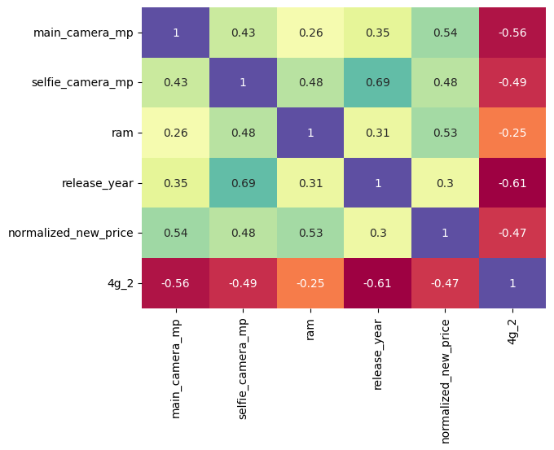

```python
sns.heatmap(data=recell[["main_camera_mp",
                         "selfie_camera_mp","ram","release_year",
                         "normalized_new_price","4g_2"]].corr(),annot=True,cbar=False,cmap="Spectral")
```

There is a nominal negative correlation between 4g_2 and release_year (-0.61) and release_year and selfie_camera_mp (0.69). I don't think the correlation between these variables is strong. However, I could drop release_year just to see what happens to R_squaered and go from there.

```python
X_train7=X_train6.drop(["release_year"],axis=1)
ols_model_7=sm.OLS(y_train,X_train7)
olsresidue_7=ols_model_7.fit()
```

```python
print(olsresidue_7.summary())
```

```
                              OLS Regression Results
=================================================================================
Dep. Variable:     normalized_used_price   R-squared:                       0.836
Model:                               OLS   Adj. R-squared:                  0.835
Method:                    Least Squares   F-statistic:                     2045.
Date:                   Thu, 11 May 2023   Prob (F-statistic):               0.00
Time:                           20:24:02   Log-Likelihood:                 55.238
No. Observations:                   2417   AIC:                            -96.48
Df Residuals:                       2410   BIC:                            -55.94
Df Model:                              6
Covariance Type:               nonrobust
========================================================================================
                           coef    std err          t      P>|t|      [0.025      0.975]
----------------------------------------------------------------------------------------
const                    1.2655      0.045     28.214      0.000       1.178       1.353
screen_size              0.0453      0.001     31.505      0.000       0.042       0.048
main_camera_mp           0.0183      0.001     13.938      0.000       0.016       0.021
selfie_camera_mp         0.0162      0.001     18.457      0.000       0.014       0.018
ram                      0.0193      0.004      4.416      0.000       0.011       0.028
normalized_new_price     0.4104      0.010     39.144      0.000       0.390       0.431
4g_2                    -0.0735      0.013     -5.517      0.000      -0.100      -0.047
==============================================================================
Omnibus:                      192.198   Durbin-Watson:                   1.913
Prob(Omnibus):                  0.000   Jarque-Bera (JB):              346.846
Skew:                          -0.561   Prob(JB):                     4.82e-76
Kurtosis:                       4.478   Cond. No.                         190.
==============================================================================

Notes:
[1] Standard Errors assume that the covariance matrix of the errors is correctly specified.
```

No significant drop in R-squared.

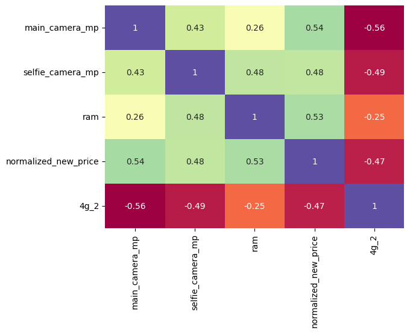

```python
sns.heatmap(data=recell[["main_camera_mp","selfie_camera_mp",
                         "ram","normalized_new_price","4g_2"]]
            .corr(),annot=True,cbar=False,cmap="Spectral")
```

I am afraid that if I keep dropping variables, I won't have any left. No other strong correlations between x variables. (Instructions taken from "What are assumptions of linear regression by R. Harshad Shah).

# 2.Test for linearity

Plot the residuals of the remaining X variables to determine whether the pattern that emerges is random or linear (Code taken from video 2.7 Linear Regression Assumptions and Inferential Hands-on. This is the case for the rest of this notebook unless otherwise specified).

```python
recell_predict=pd.DataFrame()
```

```python
recell_predict["Actual Values"]=y_train.values.flatten()
```

```python
recell_predict["Fitted Values"]=olsresidue_7.fittedvalues.values
```

```python
recell_predict["Residules"]=olsresidue_7.resid.values
```

Check the variable recell_predict.

```python
recell_predict.head()
```

|  | Actual Values | Fitted Values | Residules |
| --- | --- | --- | --- |
| 0 | 4.087488 | 3.855234 | 0.232254 |
| 1 | 4.448399 | 4.587160 | -0.138760 |
| 2 | 4.315353 | 4.272339 | 0.043014 |
| 3 | 4.282068 | 4.281121 | 0.000947 |
| 4 | 4.456438 | 4.482003 | -0.025565 |

We now used the values in recell_predict to plot the Xs on a grid to see if they result in a random or linear pattern.

```python
sns.set_style("whitegrid")
```

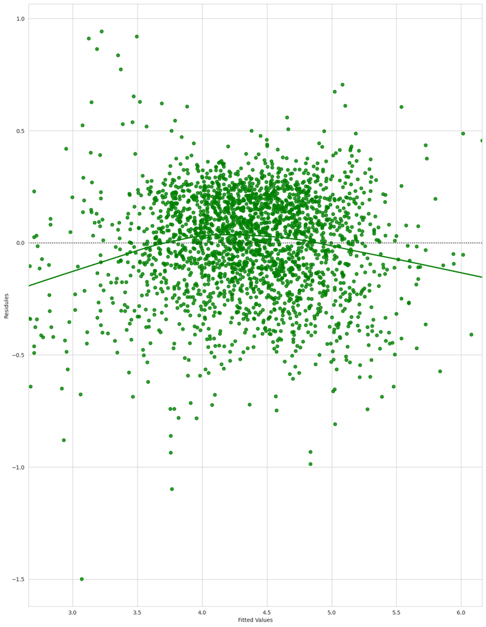

```python
plt.figure(figsize=(15,20))
sns.residplot(data=recell_predict,x="Fitted Values",y="Residules",color="green",lowess=True)
```

A visual inspection of the plotted residuals suggest that the pattern is random and not linear. There is no reason to drop any of the remaining X variables. No need for additional treatment.

# 3. Test for normality

Residuals should be normally distributed otherwise the confidence interval could become too wide or overfit or too narrow. To test for notmality, we first plot residuals using a hiostogram and a QQ plot and perform a visual inspection. Then, we perform a Shapiro-Wilks test to generate a p-value.

## Histogram

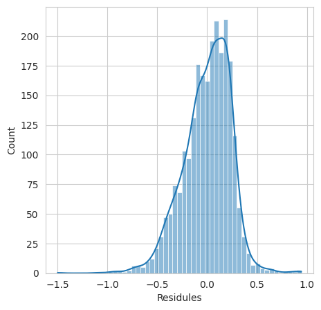

```python
plt.figure(figsize=(5,5))
sns.histplot(recell_predict["Residules"],kde=True)
plt.show()
```

This distribution does not show a perfect normal distribution. Although it is somewhat skewed to the right with a long left tail, it is generally normally distributed.

## QQ Plot

```python
import pylab
import scipy.stats as stats
```

```
((array([-3.44385758, -3.19630236, -3.05919064, ...,  3.05919064,
          3.19630236,  3.44385758]),
  array([-1.4984193 , -1.09797418, -0.98660319, ...,  0.91163355,
          0.92103776,  0.94353141])),
 (0.23359271417148778, 3.907103310161309e-15, 0.9864327295634032))
```

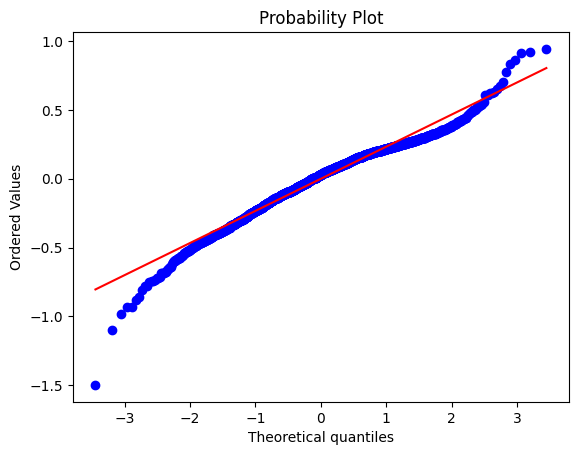

```python
stats.probplot(recell_predict["Residules"],dist="norm",plot=pylab)
```

A visual inspection suggests that thise distribution tends toward normal.

## Shapiro-Wilks Test

State the null and alternative hypothesis (Code to state null and alternative hypothesis taken from ENews Express project)

$H_o$: Residuals are normally distributed.

$H_a$: Residuals are NOT normally distributed.

```python
stats.shapiro(recell_predict["Residules"])
```

```
ShapiroResult(statistic=0.9738355875015259, pvalue=1.2527766699389244e-20)
```

Since p is significantly lower than 0.05, we reject the null hypothesis that the residuals are normally distributed strictly speaking. However, since visual inspection of other measures tends toward normal, we accept the conclusion of normalcy.

## 4.Homoscedascity versus Heteroscredascity

Is the variance of the residuals is symmetrical across the line of regression? A hetroscedastic pattern indicates the presence of outliers, which skew the results. A p-value genreated from the goldfledquandt test is used to make this determination.

## Null and alternative hypptheses

$H_o$: The variance of the residuals is symmetrical accross the distribution.

$H_a$: The variance of the residuals is NOT symmetrical across the distribution.

```python
import statsmodels.stats.api as sms
```

```python
from statsmodels.compat import lzip
```

```python
name=["F statistic","p-value"]
```

```python
test=sms.het_goldfeldquandt(recell_predict["Residules"],X_train7)
```

```python
lzip(name,test)
```

```
[('F statistic', 1.0623060376284026), ('p-value', 0.14749079912843824)]
```

Since the p-value of 0.1475 is greater than 0.05, we fail to the null hypothesis that the distribution of the variance of reiduals is homoscedastic.

## Final Model

The final itteration is olsresidue_7.

```python
print(olsresidue_7.summary())
```

```
                              OLS Regression Results
=================================================================================
Dep. Variable:     normalized_used_price   R-squared:                       0.836
Model:                               OLS   Adj. R-squared:                  0.835
Method:                    Least Squares   F-statistic:                     2045.
Date:                   Thu, 11 May 2023   Prob (F-statistic):               0.00
Time:                           21:03:34   Log-Likelihood:                 55.238
No. Observations:                   2417   AIC:                            -96.48
Df Residuals:                       2410   BIC:                            -55.94
Df Model:                              6
Covariance Type:               nonrobust
========================================================================================
                           coef    std err          t      P>|t|      [0.025      0.975]
----------------------------------------------------------------------------------------
const                    1.2655      0.045     28.214      0.000       1.178       1.353
screen_size              0.0453      0.001     31.505      0.000       0.042       0.048
main_camera_mp           0.0183      0.001     13.938      0.000       0.016       0.021
selfie_camera_mp         0.0162      0.001     18.457      0.000       0.014       0.018
ram                      0.0193      0.004      4.416      0.000       0.011       0.028
normalized_new_price     0.4104      0.010     39.144      0.000       0.390       0.431
4g_2                    -0.0735      0.013     -5.517      0.000      -0.100      -0.047
==============================================================================
Omnibus:                      192.198   Durbin-Watson:                   1.913
Prob(Omnibus):                  0.000   Jarque-Bera (JB):              346.846
Skew:                          -0.561   Prob(JB):                     4.82e-76
Kurtosis:                       4.478   Cond. No.                         190.
==============================================================================

Notes:
[1] Standard Errors assume that the covariance matrix of the errors is correctly specified.
```

# Predictions

```python
olsresidue_7.params
```

```
const                   1.265480
screen_size             0.045298
main_camera_mp          0.018326
selfie_camera_mp        0.016181
ram                     0.019266
normalized_new_price    0.410445
4g_2                   -0.073464
dtype: float64
```

All parameter values are less than 2.00. The highest is normalized_new_price with a value of 0.410 and the lowest is 4g_2 with a value of -0.073.

# Check final training performance and run the test.

## 1. Check columns.

```python
X_train7.columns
```

```
Index(['const', 'screen_size', 'main_camera_mp', 'selfie_camera_mp', 'ram',
       'normalized_new_price', '4g_2'],
      dtype='object')
```

## 2. Drop unnecessary columns from test model.

```python
X_test2=X_test.drop(["int_memory","battery","weight","release_year","days_used","5g_2"],axis=1)
```

```python
X_test2.columns
```

```
Index(['const', 'screen_size', 'main_camera_mp', 'selfie_camera_mp', 'ram',
       'normalized_new_price', '4g_2'],
      dtype='object')
```

## 3.Transform 4g_2 into a positive number by squared function.

```python
X_test2["4g_2"]=np.square(X_test2["4g_2"])
```

## 3. Make predictions.

```python
y_predict=olsresidue_7.predict(X_test2)
```

NOTE: In the future, it would be helpful for an instructor to explain why the x variable for train and test must be capital X in order for the code to run without error.

## 5. Check RMSE (Root Mean Square Error) train and test data.

```python
rmse_1=np.sqrt(mean_squared_error(y_train,recell_predict["Fitted Values"]))
```

```python
rmse_1
```

```
0.23650342344230818
```

```python
rmse_2=np.sqrt(mean_squared_error(y_test,y_predict))
```

```python
rmse_2
```

```
0.24107001382893165
```

## 7. Check MAE (Mean Absolute Error) for train and test.

```python
mae_1=mean_absolute_error(y_train,recell_predict["Fitted Values"])
```

```python
mae_1
```

```
0.18561994344724
```

```python
mae_2=mean_absolute_error(y_test,y_predict)
```

```python
mae_2
```

```
0.18540332173987706
```

The value for rme_1 is 0.1856 and rme_2 is 0.1854 rounded to 0.186 and 0.185. There is only one thousanth of a difference between these two values. Therefore, it is safe to say that they are closely fitted.

## Actionable Insights and Recommendations

# ##LR final equation

```python
Equation="recell"
print (Equation,end=" ")
for i in range (len(X_train7.columns)):
  if i ==0:
    print(olsresidue_7.params[i],"t",end=" ")
  elif i !=len(X_train7.columns)-1:
    print(olsresidue_7.params[i],"*(",X_train7.columns[i],")","+",end=" ")
  else:
    print(olsresidue_7.params[i],"*(",X_train7.columns[i],")")
```

```
recell 1.265479949602914 t 0.045297701893748855 *( screen_size ) + 0.018326299904128856 *( main_camera_mp ) + 0.016181436151031528 *( selfie_camera_mp ) + 0.01926564091693383 *( ram ) + 0.41044481751702167 *( normalized_new_price ) + -0.07346382162092159 *( 4g_2 )
```

# **Conclusion**

1. Both train and test rmse are comparable at 0.24 each. Therefore, there is no indication of model overfitting.
2. Results from MAE tests indicate that the final iteration, olsresidue_7, is able to predict normalized used prices within a mean error of 0.185 units using X_test2.
3. Olsresidue_7 is both a good predictor of future normalized_used_price and also useful to make inferences about which variables influence normaized used price. Olsresidue_7 can explain 83.6% of normalized used price. The other 16.4% would be explained by vaiables that were not included in the model.
4. The variable with the greatest impact on normalized used price was normalized new price. Of the 83.6% of normalized used price that can be explained by the olsresidue_7 model, 41% or 34% in total, can be explained by normalized used price. No other variable has close to that much influence on normalized used price although the closest is 4g_2 at -7.3% of 83.6 or -6% of the total. This suggsests that the best predictor of a used phone price is what the phone cost when it was new. Unfortunately, this model does not explain whether the price that is set means the phone will hold its value when it moves from the new to the used market or if it is what a consumer is actually willing to pay for a used phone. Actual cost was not a variable available in this data set.
5. If this information were shared with a sales team in a final report, it would be helpful to understand the calculation that was set to detemine both noramlized new and used prices. The least expensive used phone I could find on the internet was $36. So, these two variables do not really explain actual prices such as the wholesale price business would pay to aquire devices or that a consumer would pay when they purchased a device in a retail setting.